# NIPM Singularity Containers

1. Singularity
   - Singularity container use on val
   - Singularity: container software
2. Shell into an instance
3. Run with the exec command

## 1. Singularity

Singularity is a software application that allow users to have ‘full control’ over their operating system without the need for any ‘super-user’ privileges using the notion of containers. Singularity can give the user the freedom they need to install the applications, versions, and dependencies for their workflows without impacting the system in any way. For more detailed documentation on singularity see https://singularity-docs.readthedocs.io/en/latest/.

### 1.1 Singularity container use on val

Atty and Val are the compute clusters for NIPM. Atty (atty.nipm.unlv.edu) is the storage server. It has 5 55TB disks and additional storage clusters. Val (val.nipm.unlv.edu) is the compute server. It has 8 nodes with 80 cores on each node.

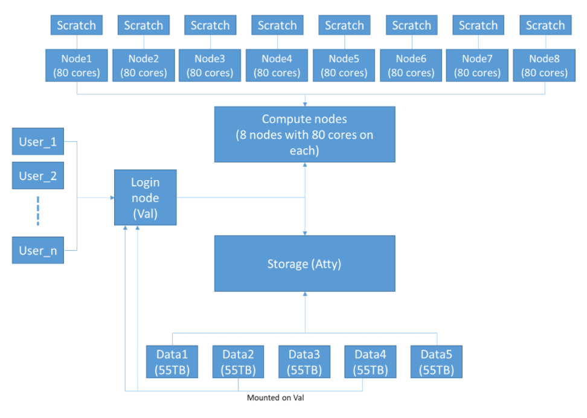

### 1.2 Singularity: container software

When running jobs on val, we can use singularity containers. I have shared two container images under `/data2/han_lab/singularity`. `py37.ml.mkl.sif`: includes python3.7, sklearn, and other machine learning related software. `rnaseq.sif`: includes fastqc, samtools, STAR, stringtie, hisat, and many more RNA-seq related software. The complete list of software can be found in the files `py37.ml.list` and `rnaseq.list`.

**It is important that you copy the image over to the node you plan to run jobs on and invoke the local version of the image that you copied over.** Having the software on atty and running them on val nodes leads to unnecessary network IO that significantly slows the jobs. Network IO between val nodes and atty is one of the most serious bottlenecks of performance. Do not invoke the container that is residing on atty directly.

For example, to use the py37.ml.mkl container on node02

```bash
ssh node02
cp /data2/han_lab/singularity/py37.ml.mkl.sif /scratch/han_lab/
```

Once you have the image on a local space on one of the nodes, you can run the image. There are two ways to run the image.

## 2. ‘Shell’ into an ‘instance’

You can make an ‘instance’ that you can shell into and out of like any other machine. This instance will stay running persistently as you log out and log into the nodes, and you can shell into the machine multiple times and check on the jobs progress.

Make sure to bind all the atty disks that you will need read/write access to with the `--bind` option.

```bash
singularity instance start --bind /data1,/data2,/data4,/scratch /scratch/han_lab/py37.ml.mkl.sif node02
singularity instance list
singularity shell --writable instance://node02
```

```bash
$ singularity instance start --bind /data1,/data2,/data4,/scratch /scratch/han_lab/py37.ml.mkl.sif node02
INFO:    instance started successfully
$ singularity instance list
INSTANCE NAME    PID      IP              IMAGE
node02           9938                     /scratch/han_lab//py37.ml.mkl.sif
$ singularity shell --writable instance://node02
(py37.ml.mkl) Singularity>
```

Once you are inside the container after the shell command, you will see a different prompt. `(py37.ml.mkl) Singularity>`

After that it is the same as running any other linux environment. Once you have finished running your jobs, **remember to stop the instance and remove your copy of the container.** List the name of your instances and stop them with the commands below.

```bash
singularity instance list
singularity instance stop node02
```